# R Basic Concepts

Jürgen Wilbert

University of Münster

2026-01-08

## Goals

- Basic concepts of the R language
- Object types: numbers, logic values, characters
- object structures: vectors, factors, data frames, lists

# Basic concepts

## Functions

- With a *function* you command the computer to do something.
- *functions* have a function name (e.g., `mean`, `sqrt`).
- *functions* take **arguments** to specify what to do.
- *arguments* have argument names as well.
- functions **always** consist of a function name followed by brackets.

`function_name(argument_name_1 = value, argument_2 = value, ...)`

## Examples

`sqrt()` calculates the square root

```r
sqrt(x = 16)
```

```
[1] 4
```

You can omit the argument name if it is the first argument

```r
sqrt(16)
```

```
[1] 4
```

Even without arguments you still need the brackets

```r
date()
```

```
[1] "Thu Oct 30 15:24:22 2025"
```

## Comments

It is good practice to add comments and notes to your code.  
Everything that is written behind a `#` will not be executed as code.  
If you want a comment to span across several line, you have to begin each line with a `#` symbol.

```r
# This is a comment
# across multiple lines
```

Within RStudio, you can use comments to create headers by ending a comment line with four `-` signs:

```r
# section 2 ----
```

You can jump through your code by the list a the bottom of your source panel or, after activating the outline panel, at the right of your source panel:

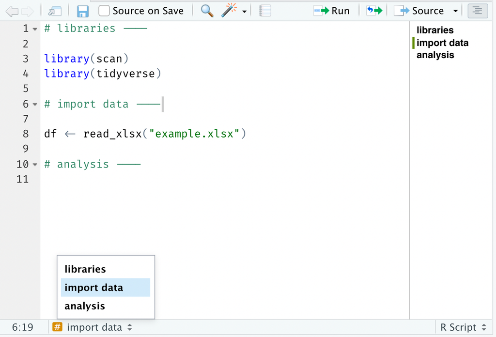

## Help files

```r
# Function
help("sqrt")

# Short cut
?sqrt
```

… or use the bottom-right help panel in R Studio

## Task

Take a look at the `mean()` function (hint: use the `help()` function):  
What *arguments* could be specified?

```r
help("mean")
?mean
```

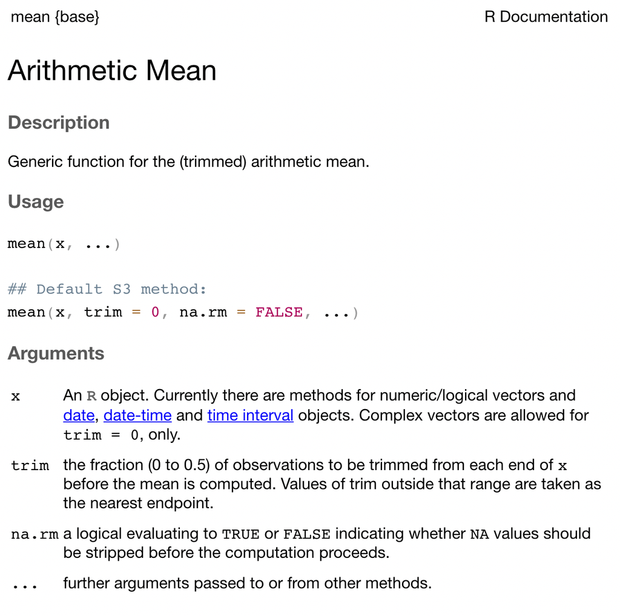

## Operations

Operations are a special kind of functions that have a shortcut.

```r
# function `assign` and the short cut
assign(x = "y", value = 10)

y <- 10
```

.

```r
# function `+`
"+"(e1 = 10, e2 = 10)

10 + 10
```

.

```r
# function `print`
print(x = y)

y
```

## Objects

Objects have an object name and contain data.  
The data are assigned to an object with the `<-` or `=` operator.

```r
x <- 10
```

You can see the value(s) of an object with the `print()` function, or by just typing the object name:

```r
print(x)
x
```

Objects can be used for operators and arguments in functions:

```r
x <- 16
y <- 13

x * y
sqrt(x)
```

You can write the return values of a function into a new object:

```r
z <- sqrt(x)
z
```

And you can combine these:

```r
exp(z) + sqrt(y)
```

## Task

Assign the values `40 and 24` to the variables `a and b`.  
Calculate the square root of the sum of `a and b`.

## Task - solution

Assign the values `40 and 24` to the variables `a and b`.  
Calculate the square root of the sum of `a and b`.

```r
a <- 40
b <- 24
sqrt(a + b)
```

```
[1] 8
```

# Data classes

## Data types

The data of objects can be numbers, text or TRUE/FALSE values. These are called **data types**

- **Numeric**: e.g. Integer or decimal numbers `1, 1.35`
- **Character**: Always between ” ” or ’ ’ signs: `"Doctor", 'House'`
- **Logical**: `TRUE, FALSE`

```r
x <- 10
y <- "Hello world!"
z <- FALSE
```

## Data structures

Data are organized in structures:

- **Vectors**: A series of elements of the same data type.
- **List**: A series of elements, each element can be of any data type or data structure.
- **Data Frames**: A list with one vector for each element and all vectors of the same length
- **Matrix**: A two dimensional table with values of the same data type.
- **Array**: Like a matrix but with more dimensions.

## Data structures

Data are organized in structures:

- **Vectors**: A series of elements of the same data type.
- **List**: A series of elements, each element can be of any data type or data structure.
- **Data Frames**: A list with one vector for each element and all vectors of the same length.
- **Matrix**: A two dimensional table with values of the same data type.
- **Array**: Like a matrix but with more dimensions.

# Vectors

## How to build a vector

You create a vector with the `c()` function:

```r
c(2, 4, 6, 3, 7)
```

```
[1] 2 4 6 3 7
```

```r
y <- c(2, 4, 6, 3, 7)
y
```

```
[1] 2 4 6 3 7
```

The colon `:` operator creates a numerical sequence:

```r
1:10
```

```
 [1]  1  2  3  4  5  6  7  8  9 10
```

This is a shortcut for `seq(1, 10)`

You can build a vector of any data type:

```r
firstname <- c("Dustin", "Mike", "Will")
curly <- c(TRUE, FALSE, FALSE)
age <- c(9, 11, 10)
```

But do not mix data types in a vector. You will get an error or they are internally changed to fit one data type:

```r
age <- c("quite young", 10, 12, "very old")
age
```

```
[1] "quite young" "10"          "12"          "very old"
```

Here `10` and `12` are changed to a character data type `"10"` and `"12"`.

## Task

Create a vector (named `friends` comprising four names of your friends.

## Task - solution

Create a vector (named `friends` comprising four names of your friends.

```r
friends <- c("Matthias", "Markus", "Thomas", "Christian")
```

## Combining vectors to new vectors

When an object is a vector it can be reused within the `c()` function to build a new vector:

```r
x <- c(3, 5, 7)
c(x, 5, 8, 9)
```

```
[1] 3 5 7 5 8 9
```

## Combining vectors to new vectors

Be careful not to confuse an object name with a character:

```r
x <- c("A", "B", "C")
c("x", "D", "E", "F")
```

```
[1] "x" "D" "E" "F"
```

```r
c(x, "D", "E", "F")
```

```
[1] "A" "B" "C" "D" "E" "F"
```

```r
c(A, B, C)
```

```
Error: object 'A' not found
```

## Task

- Create two vectors:  
  `x <- c("I", "am", "a")` and `y <- "person!"`
- Now create a new vector by reusing `x` and `y` that looks like this when printed:  
  `[1] "I" "Am" "a" "cool" "person!"`

## Task - solution

```r
x <- c("I", "am", "a")
y <- "person!"
c(x, "cool", y)
```

```
[1] "I"       "am"      "a"       "cool"    "person!"
```

Use the `paste()` function to create a single string.  
The argument `collapse` defines a character string to set between elements:

```r
paste(c(x, "cool", y), collapse = " ")
```

```
[1] "I am a cool person!"
```

## Missing values

A missing value is represented with `NA` (**N**ot **A**vailable).

```r
age <- c(9, NA, 11)
name <- c("Tick", "Trick", NA)
age
```

```
[1]  9 NA 11
```

```r
name
```

```
[1] "Tick"  "Trick" NA
```

## Task

1. Create a vector with the values  
   `2, 5, 7, 4, 7, 2, 6`.
2. Create a vector with the values  
   `2, NA, 7, 4, NA, 2, 6`.
3. Calculate the `mean` of these two vectors.
4. Note: Use the `mean()` function to calculate the mean.  
   Note: Read through `?mean` if you encounter problems.

## Task - solution

```r
x1 <- c(2, 5, 7, 4, 7, 2, 6)
x2 <- c(2, NA, 7, 4, NA, 2, 6)

mean(x1)
```

```
[1] 4.714286
```

```r
mean(x2)
```

```
[1] NA
```

```r
mean(x2, na.rm = TRUE)
```

```
[1] 4.2
```

## Named vectors

A named vector is a vector with a name for each element:

```r
age <- c(James = 34, Hella = 30, Armin = 43)
age
```

```
James Hella Armin
   34    30    43
```

```r
glasses <- c(James = TRUE, Hella = FALSE, Armin = TRUE)
glasses
```

```
James Hella Armin
 TRUE FALSE  TRUE
```

You get and set the names of a named object with the `names()` argument:

```r
names(age)
```

```
[1] "James" "Hella" "Armin"
```

```r
names(age) <- c("Judith", "Jerom", "Klaus")
age
```

```
Judith  Jerom  Klaus
    34     30     43
```

## Converting vectors

the `as` functions convert vectors between data types:

```r
as.character(1:5)
```

```
[1] "1" "2" "3" "4" "5"
```

```r
as.numeric(c(FALSE, TRUE, FALSE))
```

```
[1] 0 1 0
```

```r
as.logical(c(0,1,0,1,1))
```

```
[1] FALSE  TRUE FALSE  TRUE  TRUE
```

```r
as.numeric(c("4711", "0814", "007"))
```

```
[1] 4711  814    7
```

But unexpected results may occur:

```r
as.numeric(c("1", "2", "3.1", "3,2"))
```

```
[1] 1.0 2.0 3.1  NA
```

```r
as.logical(c(1,0,1,0,1,3))
```

```
[1]  TRUE FALSE  TRUE FALSE  TRUE  TRUE
```

# Factors

## A factor

A factor is a vector with labels for levels.  
A factor is created with the `factor()` function.  
The `levels` argument defines the possible factor levels.  
The `labels` argument defines the corresponding labels.

Example:

```r
sen <- factor(
  c(1, 0, 1, 0, 0, 0),
  levels =  c(0, 1, 2),
  labels = c("Without_SEN", "With_SEN", "unclear")
)
sen
```

```
[1] With_SEN    Without_SEN With_SEN    Without_SEN Without_SEN Without_SEN
Levels: Without_SEN With_SEN unclear
```

## Task

Build a factor for `gender` with the labels `male, female, non-binary`. Include a vector for six fictitious gender values.

## Task - solution

Build a factor for `gender` with the labels `male, female, non-binary`. Include a vector for six fictitious gender values.

```r
gender <- factor(
  c(1, 3, 2, 1, 2, 1),
  levels = 1:3,
  labels = c("male", "female", "non-binary")
)
gender
```

```
[1] male       non-binary female     male       female     male
Levels: male female non-binary
```

# Data frames

## How to build a data frame

Data frames are the standard object for storing research data. They contain variables (columns) and cases (rows). A data frame is created with the `data.frame()` function.

```r
# For better convenience I have inserted additional line-breaks and spaces
study <- data.frame(
  sen    = c(0, 1, 0, 1, 0, 1),
  gender = c("M", "M", "F", "M", "F", "F"),
  age    = c(12, 13, 11, 10, 11, 14),
  IQ     = c(90, 85, 90, 87, 99, 89)
)
study
```

| sen | gender | age | IQ |
| --- | --- | --- | --- |
| 0 | M | 12 | 90 |
| 1 | M | 13 | 85 |
| 0 | F | 11 | 90 |
| 1 | M | 10 | 87 |
| 0 | F | 11 | 99 |
| 1 | F | 14 | 89 |

## Extracting a variable from a data frame

Variables within a data frame are extracted with double square brackets.

```r
study[["sen"]]
```

```
[1] 0 1 0 1 0 1
```

```r
study[["IQ"]]
```

```
[1] 90 85 90 87 99 89
```

An alternative approach is to use the `$` sign:

```r
study$sen
```

```
[1] 0 1 0 1 0 1
```

## Extracting a variable with a variable

You can use an object to extract a variable:

```r
variable <- "gender"
index <- 2
study[[variable]]
```

```
[1] "M" "M" "F" "M" "F" "F"
```

```r
study[[index]]
```

```
[1] "M" "M" "F" "M" "F" "F"
```

# Lists

## How to construct a list

Lists are the most versatile data structures in R and are very important for understanding R.

A list is a series of elements with arbitrary data types and structures. A list is constructed with the `list()` function

```r
list(1:3, "Hallo!", TRUE)
```

```
[[1]]
[1] 1 2 3

[[2]]
[1] "Hallo!"

[[3]]
[1] TRUE
```

It is best to name list elements:

```r
my_list <- list(
  numbers = 1:3,
  string = "Hallo!",
  logical = TRUE
)
my_list
```

```
$numbers
[1] 1 2 3

$string
[1] "Hallo!"

$logical
[1] TRUE
```

## Extracting list elements

You can extract a list element with `[[` or `$` signs:

```r
my_list[["numbers"]]
```

```
[1] 1 2 3
```

```r
my_list[[1]]
```

```
[1] 1 2 3
```

```r
my_list$numbers
```

```
[1] 1 2 3
```

lists can be very complex with lists nested in lists:

```r
complex_list <- list(
  list_in_list = list(A = 1, B = 1:3),
  list_in_list_of_a_list = list(C = list(D = 4), E = 5)
)
complex_list
```

```
$list_in_list
$list_in_list$A
[1] 1

$list_in_list$B
[1] 1 2 3


$list_in_list_of_a_list
$list_in_list_of_a_list$C
$list_in_list_of_a_list$C$D
[1] 4


$list_in_list_of_a_list$E
[1] 5
```

The `str()` function returns the structure of an R object

```r
str(complex_list)
```

```
List of 2
 $ list_in_list          :List of 2
  ..$ A: num 1
  ..$ B: int [1:3] 1 2 3
 $ list_in_list_of_a_list:List of 2
  ..$ C:List of 1
  .. ..$ D: num 4
  ..$ E: num 5
```